# Linux w Systemach Wbudowanych

Piotr Zawadzki

2025-12-12

# **Ćwiczenie 6**

# Magistrala I2C

## 1. **Wprowadzenie**

Magistrala I2C (Inter-Integrated Circuit) to popularny standard komunikacyjny stworzony przez firmę Philips w latach 80. XX wieku. Służy do komunikacji pomiędzy różnymi układami elektronicznymi, takimi jak mikrokontrolery, pamięci, przetworniki analogowo-cyfrowe czy czujniki, w ramach jednej platformy urządzenia. Jest szczególnie ceniona za swoją prostotę implementacji i elastyczność, co czyni ją idealnym rozwiązaniem dla aplikacji o niskiej przepustowości, takich jak systemy wbudowane.

I2C wykorzystuje dwie linie sygnałowe: linię danych (SDA - Serial Data Line) oraz linię zegara (SCL - Serial Clock Line). Obie linie są otwarto-drenowe, co oznacza, że układy podłączone do magistrali mogą wymuszać niski stan logiczny, ale do stanu wysokiego wymagają rezystorów podciągających. Dzięki temu magistrala jest prostsza w konstrukcji i umożliwia łatwe współdzielenie linii przez wiele urządzeń. Komunikacja w I2C opiera się na modelu master-slave. Urządzenie master inicjuje transmisję danych i generuje sygnał zegarowy na linii SCL. Urządzenia slave reagują na żądania mastera, przesyłając dane w odpowiedzi na przesłane komendy. W typowej konfiguracji jedno urządzenie pełni rolę mastera, ale standard I2C pozwala również na implementację bardziej złożonych konfiguracji, w których wiele urządzeń może odgrywać tę rolę w różnych momentach. W przeciwieństwie do innych rozwiązań, takich jak magistrala UART, w I2C nie ma osobnych linii do nadawania i odbioru danych – SDA jest linią dwukierunkową. Częstotliwości pracy I2C mogą się różnić w zależności od standardu: 100 kHz (Standard-mode), 400 kHz (Fast-mode), 1 MHz (Fast-mode Plus), czy nawet 3,4 MHz (High-speed mode). Każdy węzeł magistrali ma swój unikalny adres, a podczas transmisji zawsze występuje urządzenie inicjujące – master. W warstwie fizycznej kluczowe znaczenie ma odpowiedni dobór rezystorów podciągających, który zależy m.in. od częstotliwości taktowania i pojemności całej magistrali.

Magistrala I2C może obsługiwać wiele urządzeń na jednym zestawie linii SDA i SCL. To eliminuje konieczność stosowania wielu połączeń, co jest szczególnie istotne w projektach o ograniczonej przestrzeni. Maksymalna liczba urządzeń zależy w praktyce od jej konfiguracji elektrycznej: pojemności elektrycznej linii sygnałowych i wartości rezystorów podciągających. Dzięki swojej prostocie i wszechstronności magistrala I2C jest szeroko stosowana w systemach wbudowanych, urządzeniach IoT, automatyce przemysłowej oraz sprzęcie konsumenckim. Jej ograniczenia, takie jak niska przepustowość i ograniczona długość magistrali (z powodu pojemności linii), są rekompensowane przez łatwość integracji i niski koszt implementacji.

## 2. Warstwa fizyczna

Warstwa fizyczna magistrali I²C opiera się na dwóch liniach: SDA (Serial Data) oraz SCL (Serial Clock). Obie linie są typu otwarty dren (open-drain) lub otwarty kolektor (open-collector), co oznacza, że urządzenia podłączone do magistrali mogą jedynie wymuszać stan niski (logiczne zero). Do uzyskania stanu wysokiego na liniach wykorzystuje się rezystory podciągające, które są przyłączone do dodatniego zasilania (np. 3,3 V lub 5 V). Dzięki temu rozwiązaniu, jeśli żadne urządzenie nie wymusza stanu niskiego, linie utrzymują się w stanie wysokim.

### Konfiguracja elektryczna linii

[figure not shown]

Rys. 6.1 Idea łączenia urządzeń na magistrali I2C.

Powyższy rysunek prezentuje dwie linie magistrali (SDA i SCL) z rezystorami podciągającymi do dodatniego napięcia. Konfiguracja w urządzeniach interfejsu w formie *open-drain* lub *open-collector* pozwala na sterowanie stanem linii przez jej „zwieranie” do masy. Rezystor podciągający zapewnia wymuszenie stanu wysokiego w chwilach, gdy żadne urządzenie nie wymusza stanu niskiego. W takiej metodzie kodowania ważna jest synchronizacja działań urządzeń korzystających z magistrali. Służą do tego linia zegarowa SCL oraz mechanizm arbitrażu.

### Kodowanie bitów

Transmisja w magistrali I2C odbywa się w sposób synchroniczny. Master steruje zegarem na linii SCL, a dane są przesyłane w postaci bitów na linii SDA. Protokół opiera się na sekwencjach, takich jak:

- **Start**: Wskazuje początek transmisji, master obniża linię SDA, gdy SCL jest w stanie wysokim. Adresowanie: Master wysyła adres urządzenia slave oraz bit określający kierunek transmisji (odczyt/zapis).
- **Dane**: Transmisja danych odbywa się w bajtach, a każde przesłanie bajtu kończy się bitami potwierdzenia (ACK/NACK) przesyłanymi przez stronę odbierającą.
- **Stop**: Wskazuje zakończenie transmisji, master podnosi linię SDA, gdy SCL jest w stanie wysokim.
1. **Stan bezczynności (Idle State)**
- **Opis**: W stanie bezczynności linie SDA i SCL są utrzymywane na wysokim poziomie logicznym (logika 1) przez rezystory podciągające. Oznacza to, że magistrala jest wolna, i żadna komunikacja obecnie się nie odbywa.
- **Znaczenie**: Żadne urządzenie nie wymusza stanu niskiego na liniach, więc rezystory podciągające utrzymują je w stanie wysokim. Jest to domyślny stan spoczynkowy magistrali.
2. **Stan startu (Start Condition)**
- **Definicja**: Stan startu sygnalizuje rozpoczęcie komunikacji. W I2C tylko *master* może rozpocząć transmisję. Urządzenia *slave* są informowane o rozpoczęciu transmisji poprzez odpowiednią zmianę stanu linii SDA i SCL.
- **Szczegóły czasowe**:
  - Urządzenie master wymusza **stan niski na linii SDA**, podczas gdy **linia SCL pozostaje w stanie wysokim**.
  - Jest to rozpoznawane jako stan startu przez wszystkie urządzenia na magistrali.
- **Kluczowe cechy**:
  - Przejście linii SDA z wysokiego na niski, gdy SCL jest w stanie wysokim, jest unikalne dla stanu startu.
  - Stan startu służy do powiadamiania wszystkich urządzeń na magistrali o rozpoczęciu transmisji.

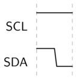

  Rys. 6.2 Warunek startu transmisji.

3. **Kodowanie wartości bitów informacji (Information Bit Value Encoding)**
- **Definicja**: Bity danych (0 i 1) są przesyłane na linii SDA i synchronizowane z linią zegara SCL.
- **Szczegóły czasowe**:
  - Bity danych są zmieniane/ustawiane tylko **podczas niskiego stanu zegara SCL**.
  - Linia SDA musi pozostawać stabilna (niezmienna), gdy linia SCL jest w stanie wysokim, ponieważ wtedy odbiornik próbuje odczytać wartość bitu.
  - Jakakolwiek zmiana na linii SDA musi nastąpić, **gdy SCL jest w stanie niskim** (pomiędzy cyklami zegara).
  - Wartość linii SDA dla stanu wysokiego linii zegara odpowiada wartości bitu
- **Kodowanie bitów**:
  - Logika 0: Linia SDA jest wymuszana na niski stan podczas odpowiedniego impulsu zegara.
  - Logika 1: Linia SDA jest zwalniana (lub utrzymywana w stanie wysokim) podczas odpowiedniego impulsu zegara.
- **Rozciąganie zegara (Clock Stretching)**: Urządzenie slave może utrzymywać linię SCL w stanie niskim, aby opóźnić następny cykl zegara i zyskać więcej czasu na przetworzenie danych.

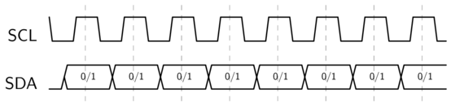

  Rys. 6.3 Stany elektryczne linii sygnałowych podczas transmisji bitów.

1. **ACK Po Każdym Bajcie**
- Po przesłaniu każdego bajtu danych (8 bitów) na linii SDA przez stronę nadającą (*master* lub *slave*, w zależności od kierunku transmisji), urządzenie odbierające musi wysłać ACK.
- Potwierdzenie (ACK) to pojedynczy bit.
- Po przesłaniu 8 bitów danych master generuje dziewiąty impuls zegarowy na linii SCL.
- Nadajnik zwalnia linię SDA, a odbiornik ściąga ją do niskiego stanu podczas tego 9-tego impulsu zegarowego.

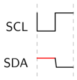

  Rys. 6.4 Bit potwierdzenia - ACK

- Ostatni bajt jest potwierdzany przez NACK, który osiąga się analogicznie do ACK, z tym że SDA jest sterowana do stanu wysokiego.

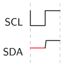

  Rys. 6.5 Brak bitu potwierdzenia - NACK

1. **Stan stopu (Stop Condition)**
- **Definicja**: Stan stopu sygnalizuje zakończenie komunikacji.
- **Szczegóły czasowe**:
  - Urządzenie master przestaje generować sygnał zegarowy pozostawiając **linię SCL w stanie wysokim**. Brak stanu niskiego na sygnale SCL powoduje, że *slave* nie interesuje się stanem linii SDA, a *master* również zwalnia ją **do stanu wysokiego**.
  - Przejście linii SDA z niskiego na wysoki, gdy SCL jest w stanie wysokim, jest rozpoznawane jako stan stopu przez wszystkie urządzenia na magistrali.
- **Kluczowe cechy**:
  - Stan stopu zwalnia magistralę, pozwalając jej powrócić do stanu bezczynności.
  - Informuje wszystkie urządzenia, że bieżąca sesja komunikacji została zakończona.

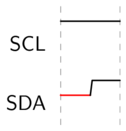

  Rys. 6.6 Stan stopu

**Podsumowanie zależności czasowych**

| **Stan** | **SCL** | **Przejście na SDA** | **Cel** |
| --- | --- | --- | --- |
| **Stan bezczynności** | Wysoki (podciągany) | Wysoki (podciągany) | Magistrala wolna |
| **Stan startu** | Wysoki | Wysoki → Niski | Rozpoczęcie komunikacji |
| **Transmisja danych** | Sterowany zegarem (H/L) | Stabilny przy wysokim SCL; zmiana przy niskim SCL | Przesyłanie bitów danych |
| **Stan stopu** | Wysoki | Niski → Wysoki | Zakończenie komunikacji |

Przestrzeganie tych reguł czasowych w protokole I2C zapewnia niezawodną komunikację między urządzeniami *master* i *slave* na wspólnej magistrali. Na poniższym wykresie przedstawiono zmiany stanów linii sygnałowych podczas transmisji jednego bajtu.

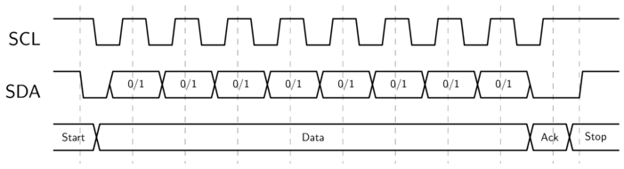

Rys. 6.7 Przebiegi czasowe linii sygnałowych podczas transmisji bajtu danych

### Sekwencje zaawansowane

1. Adresowanie 10-bitowe

W systemie adresowania 10-bitowego, do przesłania adresu urządzenia peryferyjnego wymagane są dwie ramki. Pierwsza ramka będzie składać się z kodu b11110xyz, gdzie ‘x’ jest najstarszym bitem adresu urządzenia peryferyjnego, y jest bitem 8 adresu urządzenia peryferyjnego, a z jest bitem odczytu/zapisu, jak opisano powyżej. Bit ACK pierwszej ramki zostanie potwierdzony przez wszystkie urządzenia peryferyjne, które pasują do pierwszych dwóch bitów adresu. Podobnie jak w przypadku normalnego transferu 7-bitowego, natychmiast rozpoczyna się kolejny transfer, który zawiera bity 7:0 adresu. W tym momencie adresowane urządzenie peryferyjne powinno odpowiedzieć bitem ACK. Jeśli tego nie zrobi, tryb awaryjny jest taki sam jak w systemie 7-bitowym.

Należy zauważyć, że urządzenia z adresami 10-bitowymi mogą współistnieć z urządzeniami z adresami 7-bitowymi, ponieważ wiodąca część adresu ‘11110’ nie jest częścią żadnego prawidłowego adresu 7-bitowego.

1. Powtarzane stany startu Czasami ważne jest, aby *master* mógł wymieniać kilka wiadomości za jednym razem, nie pozwalając innym *masterom* na magistrali na ingerencję. Z tego powodu zdefiniowano powtarzany stan startu. Aby wykonać powtarzany start, linia SDA może przejść w stan wysoki, gdy SCL jest niski, SCL może przejść w stan wysoki, a następnie SDA jest ponownie obniżana, gdy SCL jest wysoki. Ponieważ na magistrali nie było stanu stopu, poprzednia komunikacja nie została naprawdę zakończona i bieżący *master* utrzymuje kontrolę nad magistralą. W tym momencie może rozpocząć się transmisja następnej wiadomości. Składnia tej nowej wiadomości jest taka sama jak każdej innej wiadomości — ramka adresowa, a następnie ramki danych. Dozwolona jest dowolna liczba powtarzanych startów, a *master* będzie utrzymywał kontrolę nad magistralą, dopóki nie wyda stanu stopu.
2. Rozciąganie zegara Czasami szybkość danych *mastera* przekracza zdolność *slave* do dostarczenia tych danych. Może to być spowodowane tym, że dane nie są jeszcze gotowe (na przykład *slave* nie zakończył jeszcze konwersji analogowo-cyfrowej) lub dlatego, że poprzednia operacja nie została jeszcze zakończona (na przykład EEPROM, który nie zakończył jeszcze zapisu do pamięci nieulotnej i musi to zakończyć, zanim będzie mógł obsłużyć inne żądania). W takim przypadku niektóre urządzenia peryferyjne wykonają tzw. “rozciąganie zegara”. Nominalnie, wszystkie sygnały zegarowe są generowane przez *mastera* — *slave* po prostu umieszcza dane na magistrali lub pobiera dane z magistrali w odpowiedzi na impulsy zegarowe *mastera*. W dowolnym momencie procesu transferu danych, adresowany *slave* może utrzymać linię SCL w stanie niskim po jej zwolnieniu przez *mastera*. *Master* jest zobowiązany do powstrzymania się od dodatkowych impulsów zegarowych lub transferu danych, dopóki *slave* nie zwolni linii SCL.

## 3. Warstwa łącza

Każde urządzenie podłączone do magistrali ma unikalny adres, który może być 7- lub 10-bitowy, w zależności od używanej wersji protokołu. *Master* wysyła ten adres na początku komunikacji, aby wskazać, z którym urządzeniem chce nawiązać połączenie. Urządzenia slave ignorują dane, jeśli adres w ramce startowej nie odpowiada ich własnemu.

Typowa ramka I2C składa się z następujących elementów:

1. **Start Condition (START)**:
   - Master generuje warunek START, który sygnalizuje rozpoczęcie transmisji. Jest to przejście linii SDA z poziomu wysokiego na niski, podczas gdy linia SCL pozostaje w stanie wysokim.
2. **Address Frame (Adres urządzenia)**:
   - Po warunku START, master wysyła 7-bitowy adres urządzenia docelowego. W przypadku użycia 10-bitowego adresowania, jest to rozszerzone do dwóch bajtów.
   - 8. bit ramki adresowej określa kierunek transmisji:
     - `0` – zapis (write),
     - `1` – odczyt (read).
3. **Acknowledge (ACK/NACK)**:
   - Po każdym bajcie (adresie lub danych), odbiorca musi potwierdzić odebranie danych, ustawiając linię SDA na niski poziom podczas dodatkowego cyklu zegara. Jeśli urządzenie nie potwierdzi (NACK – brak potwierdzenia), transmisja jest przerwana.
4. **Data Frames (Ramki danych)**:
   - Dane są przesyłane w 8-bitowych porcjach (bajtach), najpierw najbardziej znaczący bit (MSB). Każdy bajt jest potwierdzany przez odbiorcę (ACK/NACK).
5. **Stop Condition (STOP)**:
   - Master kończy transmisję, generując warunek STOP. Jest to przejście linii SDA z poziomu niskiego na wysoki, gdy linia SCL jest w stanie wysokim.

Proces odczytu danych z sensora za pomocą I2C można podzielić na kilka kroków:

1. **Rozpoczęcie transmisji (START)**:
   - Master generuje warunek START.
2. **Wysłanie adresu sensora**:
   - Master wysyła adres sensora wraz z bitem kierunku `0` (zapis). Sensor potwierdza odbiór (ACK).
3. **Wysłanie rejestru do odczytu**:
   - Master wysyła bajt z adresem rejestru w sensorze, z którego chce odczytać dane. Sensor ponownie potwierdza odbiór (ACK).
4. **Restart transmisji**:
   - Master generuje warunek START/RESTART ponownie, aby przejść do trybu odczytu.
5. **Adresowanie sensora z trybem odczytu**:
   - Master wysyła adres sensora, tym razem z bitem kierunku `1` (odczyt). Sensor potwierdza odbiór (ACK).
6. **Odczyt danych**:
   - Sensor zaczyna przesyłać dane w odpowiedzi na żądanie mastera. Master odbiera bajty danych i potwierdza odbiór (ACK) do przedostatniego bajtu. Po odebraniu ostatniego bajtu master wysyła brak potwierdzenia (NACK).
7. **Zakończenie transmisji (STOP)**:
   - Master generuje warunek STOP, kończąc transmisję.

Przekład takiej transakcji z wykorzystaniem adresów 7-mio bitowych przedstawiono na rysunku poniżej. Warunki start i stop zaznaczono na czerwono, warunek restartu transmisji na niebiesko.

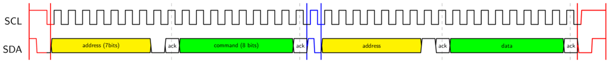

Rys. 6.7 Ilustracja struktury ramki danych - wysłanie i odbiór jednego bajtu

## 3. SMBus

SMBus (System Management Bus) jest rozwinięciem pomysłu magistrali I²C, ale wprowadzono w nim kilka ograniczeń i modyfikacji (głównie ze względu na ograniczenia patentowe). Przede wszystkim SMBus określa dokładniejsze wymagania dotyczące protokołu (jak np. timing czy reakcja na błędy) oraz standardowo pracuje z częstotliwością 100 kHz. SMBus wymaga także stosowania mechanizmów czasowych (time-out), które nie są obowiązkowe w klasycznym I²C – urządzenia nie mogą blokować magistrali na czas dłuższy niż określony w specyfikacji SMBus. Dodatkowo, w SMBus wprowadzono ściślejsze reguły dotyczące napięć zasilania, zapewniając większą kompatybilność pomiędzy urządzeniami systemowymi (np. w laptopach czy serwerach).

## 4. Korzystanie z I2C/SMBus w systemie Linux

### Konfiguracja platformy sprzętowej

Aby korzystać z magistrali I2C na platformie Raspberry Pi, konieczna jest odpowiednia konfiguracja sprzętu i systemu operacyjnego. Proces ten obejmuje edycję plików konfiguracyjnych, włączanie nakładek *Device Tree*, a także sprawdzenie dostępności odpowiednich urządzeń w systemie plików. Wszystkie te kroki są niezbędne, aby zapewnić prawidłowe działanie magistrali I2C i komunikację z podłączonymi urządzeniami.

#### **Plik `config.txt`**

Plik `config.txt` to podstawowy sposób konfiguracji sprzętu w systemie Raspberry Pi. Jest on umieszczony w partycji `/boot/` (`/boot/firmware` dla Pi5). Aby włączyć magistralę I2C, należy wprowadzić w tym pliku odpowiednią konfigurację. Domyślna konfiguracja magistrali jest już zdefiniowana w *device Tree*, tylko nieaktywna. Wystarczy ją aktywować wpisem (tak robi to narzędzie `raspi-config`)

```
dtparam=i2c_arm=on
```

To polecenie aktywuje obsługę magistrali I2C na standardowej linii I2C1, która jest głównym kanałem przeznaczonym do użytku użytkownika. Można także zmodyfikować domyślną prędkość transmisji na magistrali, dodając parametr:

```
dtparam=i2c_arm_baudrate=400000
```

Powyższa wartość ustawia częstotliwość na 400 kHz, co jest standardem dla komunikacji Fast Mode.

#### **Nakładki Device Tree**

Alternatywną, niestandardową, konfigurację można zrealizować korzystając z nakładek w katalogu `/boot/firmware/overlays`. Raspberry PI5 nieco różni się od swoich poprzedników, więc należy stosować wersję dedykowane właśnie dla tej platformy. Domyślnie na Raspberry Pi dostępne są dwie linie magistrali I2C:

- **I2C0**: Główna magistrala zarezerwowana głównie dla systemu.
- **I2C1**: Magistrala przeznaczona do użytku użytkownika.

```
dtoverlay=i2c1-pi5
```

Pomoc odnośnie opcji konfiguracyjnych nakładki można uzyskać poleceniem

```bash
dtoverlay -h i2c1-pi5
```

#### **Pliki urządzeń**

Po uzupełnieniu wpisów w `config.txt` i restarcie urządzenia, w systemie powinny pojawić się odpowiednie pliki urządzeń w katalogu `/dev/`. Każda magistrala jest reprezentowana jako osobny plik urządzenia, np.:

- `/dev/i2c-1`: Odpowiada magistrali I2C1.
- `/dev/i2c-0`: Odpowiada magistrali I2C0.

Pliki te są używane zarówno przez narzędzia wiersza poleceń, jak i przez programy użytkownika do komunikacji z urządzeniami podłączonymi do magistrali I2C.

#### **Interfejs sysfs**

Interfejs `sysfs` to ważny element systemu Linux, umożliwiający dostęp do informacji o sprzęcie w sposób strukturalny i czytelny. Informacje o dostępnych magistralach I2C można znaleźć w katalogu:

```bash
/sys/class/i2c-dev/
```

Każda magistrala posiada tutaj swój unikalny wpis, np. `i2c-1`. Dzięki temu możliwe jest programowe uzyskanie informacji o dostępnych magistralach bez potrzeby ręcznego sprawdzania plików urządzeń.

#### **Podłączanie urządzeń do magistrali**

Raspberry Pi wykorzystuje piny GPIO jako interfejs magistrali I2C (`/dev/i2c-1`). Standardowo są to:

- **SDA**: Pin GPIO 2.
- **SCL**: Pin GPIO 3.

[figure not shown]

Rys. 6.8 Przypisanie sygnałów do pinów w Raspberry Pi 5

Urządzenia należy podłączać do tych pinów wraz z podciąganiem rezystorami do linii zasilania (typowo 3.3 V lub 5 V, w zależności od wymagań urządzenia). Rezystory podciągające są często wbudowane w płytki z urządzeniami peryferyjnymi, ale jeśli ich brak, należy je dodać ręcznie, używając rezystancji rzędu 4.7 kΩ.

### Narzędzia linii komend

W systemie Linux dostępny jest zestaw narzędzi wiersza poleceń przeznaczony do pracy z magistralą I2C. Narzędzia te są częścią pakietu `i2c-tools` i umożliwiają diagnozowanie, odczyt i zapis danych, a także konfigurację urządzeń podłączonych do magistrali. Każde z tych narzędzi ma swoje specyficzne zastosowanie i jest przydatne zarówno dla deweloperów, jak i administratorów systemów wbudowanych.

#### **`i2cdetect` – wykrywanie urządzeń na magistrali**

Sprawdzenie dostępnych w systemie magistral realizuje komenda

```bash
i2cdetect -l
```

Po podaniu numeru magistrali narzędzie `i2cdetect` próbuje komunikować się z każdym możliwym adresem urządzenia (od 0x03 do 0x77) i wyświetla wyniki w formie tabeli.

Przykład użycia:

```bash
i2cdetect -y 1
```

- Opcja `-y` wyłącza pytanie o potwierdzenie przed wykonaniem skanowania.
- Liczba `1` wskazuje na numer magistrali I2C, na której ma zostać przeprowadzone skanowanie.

Wynik działania `i2cdetect` przedstawia tabelę z adresami urządzeń. Adresy, pod którymi wykryto urządzenia, są oznaczone ich wartościami szesnastkowymi, podczas gdy inne pozostają puste (`--`). Narzędzie to jest użyteczne do sprawdzenia, czy urządzenie jest poprawnie podłączone do magistrali i czy odpowiada na zapytania.

#### **`i2cdump` – podgląd zawartości urządzenia**

Narzędzie `i2cdump` pozwala na odczytanie i wyświetlenie zawartości pamięci urządzenia podłączonego do magistrali I2C. Przeprowadza ono odczyt sekwencyjny wszystkich rejestrów urządzenia, prezentując dane w formacie heksadecymalnym.

Przykład użycia:

```bash
i2cdump -y 1 0x20
```

- Numer `1` odnosi się do magistrali I2C.
- Adres `0x20` to adres urządzenia, z którego dane mają być odczytane.

Wyjście `i2cdump` jest przedstawione w formie tabeli, gdzie wiersze reprezentują wysokie bity adresów rejestrów, a kolumny niskie bity. Narzędzie to pozwala na szybkie podejrzenie zawartości pamięci urządzenia, co może być przydatne przy debugowaniu problemów z transmisją.

#### **`i2cget` – odczyt wartości z rejestru**

Narzędzie `i2cget` służy do odczytywania wartości z określonego rejestru urządzenia podłączonego do magistrali I2C. Jest przydatne, gdy potrzebny jest szybki i konkretny odczyt danych.

Przykład użycia:

```bash
i2cget -y 1 0x20 0x01
```

- `1` oznacza numer magistrali.
- `0x20` to adres urządzenia.
- `0x01` to adres rejestru, którego wartość ma zostać odczytana.

Po wykonaniu polecenia narzędzie zwraca wartość odczytaną z wybranego rejestru w formacie heksadecymalnym. Jest to użyteczne przy pracy z urządzeniami posiadającymi konfiguracje w rejestrach, takich jak czujniki lub układy sterujące.

#### **`i2cset` – zapis wartości do rejestru**

Narzędzie `i2cset` umożliwia zapisanie określonej wartości do wybranego rejestru urządzenia I2C. Jest to narzędzie niezbędne przy konfigurowaniu urządzeń, które wymagają ustawienia parametrów pracy.

Przykład użycia:

```bash
i2cset -y 1 0x20 0x01 0xFF
```

- `1` to numer magistrali.
- `0x20` oznacza adres urządzenia.
- `0x01` to adres rejestru.
- `0xFF` to wartość, która zostanie zapisana w rejestrze.

`i2cset` pozwala także na ustawienie różnych trybów transmisji, np. zapisu jednego bajtu lub bloku danych. Aby uniknąć przypadkowych błędów, zaleca się ostrożność przy korzystaniu z tego narzędzia, ponieważ nieprawidłowe wartości mogą zakłócić działanie urządzenia.

### Korzystanie z API w przestrzeni użytkownika

W systemie Linux API dla magistrali I2C pozwala użytkownikowi na komunikację z urządzeniami peryferyjnymi bezpośrednio z przestrzeni użytkownika. Dostęp do magistrali odbywa się za pomocą standardowych operacji na plikach urządzeń reprezentujących magistrale I2C, np. `/dev/i2c-1`. W API dostępne są funkcje takie jak `open`, `ioctl`, `read` i `write`, które umożliwiają pełną kontrolę nad transmisją danych. Poniżej opisano szczegóły korzystania z tego API, a także potencjalne zagrożenia wynikające z używania magistrali przez wiele aplikacji jednocześnie.

#### **Otwieranie urządzenia**

Aby rozpocząć komunikację, należy otworzyć plik urządzenia magistrali I2C za pomocą funkcji `open`. To krok wstępny, który tworzy deskryptor pliku będący uchwytem do magistrali. Deskryptor ten jest później używany w operacjach `ioctl`, `read` i `write`.

Przykład otwierania magistrali I2C:

```cpp
#include <fcntl.h>
#include <unistd.h>
#include <iostream>

int file = open("/dev/i2c-1", O_RDWR);
if (file < 0) {
    std::cerr << "Failed to open the I2C bus\n";
    return 1;
}
```

Funkcja `open` zwraca deskryptor pliku, który należy przekazać w kolejnych operacjach.

#### **Ustawianie adresu urządzenia za pomocą `ioctl`**

Magistrala I2C jest zaprojektowana tak, aby obsługiwać wiele urządzeń jednocześnie. Każde urządzenie *slave* ma swój unikalny adres. Aby komunikować się z określonym urządzeniem, należy ustawić jego adres za pomocą wywołania `ioctl` z flagą `I2C_SLAVE`. To ustawienie jest niezbędne przed rozpoczęciem operacji `read` lub `write`. Tak ustawiony adres jest automatycznie wstawiany przez sterownik kontrolera magistrali w każdej ramce oczytu lub zapisu.

Przykład ustawienia adresu urządzenia:

```cpp
#include <sys/ioctl.h>
#include <linux/i2c-dev.h>

if (ioctl(file, I2C_SLAVE, 0x20) < 0) {
    std::cerr << "Failed to acquire bus access and/or talk to slave\n";
    return 1;
}
```

Adres `0x20` to szesnastkowy adres urządzenia peryferyjnego na magistrali.

#### **Operacje `read` i `write`**

Po ustawieniu adresu urządzenia można wykonywać operacje odczytu i zapisu. Wywołanie `read` lub `write` powoduje wystawienie na linię ramki I2C, które są automatycznie tworzone przez sterownik na podstawie podanych danych.

##### **Zapis danych (`write`)**

Zapis polega na przesłaniu adresu rejestru oraz wartości do tego rejestru. Ramka danych jest konstruowana w następujący sposób:

1. Adres urządzenia (*slave*) zostaje dodany automatycznie przez sterownik.
2. Pierwszy bajt to zazwyczaj adres rejestru w urządzeniu.
3. Kolejne bajty to dane do zapisania.

Przykład zapisu danych:

```cpp
unsigned char buffer[2] = {0x01, 0xFF}; // Adres rejestru i wartość
if (write(file, buffer, 2) != 2) {
    std::cerr << "Failed to write to the I2C bus\n";
}
```

W powyższym przykładzie pierwszy bajt `0x01` oznacza rejestr, a drugi `0xFF` to wartość zapisywana.

##### **Odczyt danych (`read`)**

Odczyt jest bardziej złożony, ponieważ wymaga najpierw poinformowania *slave* o numerze odczytywanego rejestru. Działanie realizuje się przez zapis adresu rejestru, a następnie odczyt wartości wystawionej przez *slave*. Niektóre urządzenia *slave* umożliwiają odczyt sekwencyjny — odczyt kolejnych bajtów powoduje wystawianie zawartości kolejno po sobie następujących rejestrów.

Przykład odczytu danych (pamiętaj, że najpierw musi być ustawiony adres *slave*):

```cpp
unsigned char reg = 0x01; // Adres rejestru
if (write(file, &reg, 1) != 1) {
    std::cerr << "Failed to set register address\n";
}

unsigned char data;
if (read(file, &data, 1) != 1) {
    std::cerr << "Failed to read from the I2C bus\n";
} else {
    std::cout << "Data read: " << static_cast<int>(data) << "\n";
}
```

W tym przypadku:

1. Najpierw za pomocą `write` przesyłany jest adres rejestru.
2. Następnie za pomocą `read` odczytywana jest wartość z tego rejestru.

#### **Relacja między `ioctl`, `read` i `write`**

Funkcja `ioctl` z flagą `I2C_SLAVE` definiuje kontekst komunikacji, czyli adres *slave*, z którym wszystkie kolejne operacje będą powiązane. Dlatego każda operacja `read` i `write` zakłada, że odpowiedni adres urządzenia został wcześniej ustawiony. W przypadku magistrali dzielonej przez wiele aplikacji w środowisku wielozadaniowym taki sposób budowania ramek może prowadzić do sytuacji hazardu. Jeśli dwie aplikacje próbują jednocześnie używać tej samej magistrali, mogą one wzajemnie zmieniać adresy *slave* za pomocą `ioctl`, co prowadzi do nieoczekiwanych wyników. Przykładowo, aplikacja A ustawia adres 0x20, ale zanim wyśle dane, aplikacja B zmienia adres na 0x30. W rezultacie dane mogą zostać wysłane do niewłaściwego urządzenia.

W celu rozwiązania tego problemu system Linux umożliwia realizację odczyt lub zapisu do/z magistrali I2C w sposób atomiczny. W tym celu należy skorzystać z funkcji `ioctl` z komendą `I2C_RDWR`, która umożliwia wykonanie złożonych operacji odczytu i zapisu w ramach jednej transakcji. W takim podejściu sterownik zapewnia, że żadna inna operacja nie zostanie wykonana na magistrali w trakcie tej transakcji.

### **`I2C_RDWR` – atomiczne transakcje odczytu i zapisu**

Komenda `ioctl` o nazwie `I2C_RDWR` pozwala na wykonanie jednego lub więcej transferów (zarówno odczytu, jak i zapisu) w ramach jednej operacji. W tym trybie użytkownik definiuje listę operacji w strukturze `i2c_rdwr_ioctl_data`, która jest następnie przesyłana do sterownika.

#### Struktura `i2c_rdwr_ioctl_data`

```c
struct i2c_rdwr_ioctl_data {
    struct i2c_msg *msgs; // Wskaźnik na tablicę wiadomości I2C
    __u32 nmsgs;          // Liczba wiadomości w transakcji
};
```

#### Struktura wiadomości `i2c_msg`

Każda wiadomość określa pojedynczy transfer (odczyt lub zapis):

```c
struct i2c_msg {
    __u16 addr;    // Adres urządzenia (slave)
    __u16 flags;   // Flagi operacji (np. I2C_M_RD dla odczytu)
    __u16 len;     // Długość danych
    __u8 *buf;     // Bufor danych
};
```

#### **Przykład atomicznego zapisu i odczytu**

Poniżej znajduje się przykład kodu w C, który w jednej transakcji wykonuje zapis adresu rejestru do urządzenia, a następnie odczytuje dane z tego rejestru.

```cpp
#include <iostream>
#include <linux/i2c-dev.h>
#include <sys/ioctl.h>
#include <fcntl.h>
#include <unistd.h>
#include <cstring> // For memset

int main() {
    int file = open("/dev/i2c-1", O_RDWR);
    if (file < 0) {
        std::cerr << "Failed to open the I2C bus\n";
        return 1;
    }

    // Adres urządzenia slave
    int addr = 0x20;

    // Przygotowanie buforów danych
    unsigned char reg = 0x01; // Adres rejestru do odczytu
    unsigned char data;       // Bufor na odczytane dane

    // Definicja wiadomości I2C
    struct i2c_msg messages[2];

    // Wiadomość zapisu: przesłanie adresu rejestru
    messages[0].addr = addr;
    messages[0].flags = 0; // Zapis (flagi = 0)
    messages[0].len = 1;
    messages[0].buf = &reg;

    // Wiadomość odczytu: pobranie danych z rejestru
    messages[1].addr = addr;
    messages[1].flags = I2C_M_RD; // Odczyt
    messages[1].len = 1;
    messages[1].buf = &data;

    // Przygotowanie struktury dla I2C_RDWR
    struct i2c_rdwr_ioctl_data ioctl_data;
    ioctl_data.msgs = messages;
    ioctl_data.nmsgs = 2; // Dwie wiadomości: zapis i odczyt

    // Wykonanie transakcji
    if (ioctl(file, I2C_RDWR, &ioctl_data) < 0) {
        std::cerr << "Failed to perform I2C transaction\n";
        close(file);
        return 1;
    }

    // Wyświetlenie odczytanych danych
    std::cout << "Read data: " << static_cast<int>(data) << "\n";

    close(file);
    return 0;
}
```

1. **Pierwsza wiadomość (zapis):**
   - Ustawia adres rejestru, który ma zostać odczytany.
   - Dane wysyłane w tej wiadomości są zapisane w urządzeniu I2C.
2. **Druga wiadomość (odczyt):**
   - Pobiera dane z wcześniej ustawionego rejestru.
   - W ramach tego samego transferu odczytuje dane bez potrzeby ponownego ustawiania kursora.
3. **Atomowość:**
   - Operacja jest wykonywana jako pojedyncza transakcja. Jądro blokuje magistralę na czas jej wykonania, co gwarantuje, że żadne inne urządzenie lub aplikacja nie przerwie procesu.

#### **Zalety korzystania z `I2C_RDWR`**

1. **Atomowość:** Gwarantuje, że cały zestaw operacji jest wykonany jako jeden nieprzerwany transfer, co eliminuje ryzyko ingerencji innych aplikacji.
2. **Szybkość:** Zmniejsza liczbę komunikacji z magistralą, ponieważ nie trzeba oddzielnie ustawiać adresu urządzenia i rejestru.
3. **Bezpieczeństwo:** Minimalizuje błędy wynikające z równoczesnego korzystania z magistrali przez różne aplikacje.

Zadania do wykonania